# MK A7 Kickstarter

Author

Meera Kohli

### Libraries

```r
library(dplyr)
library(ggplot2)
```

### Loading Data

```r
kickstarter <- read.csv("https://drive.google.com/uc?export=download&id=1Z-hoi0x3PBYzXOm76o2ZzWWgWlR41OWO")
glimpse(kickstarter)
```

```
Rows: 378,661
Columns: 15
$ ID               <int> 1000002330, 1000003930, 1000004038, 1000007540, 10000…
$ name             <chr> "The Songs of Adelaide & Abullah", "Greeting From Ear…
$ category         <chr> "Poetry", "Narrative Film", "Narrative Film", "Music"…
$ main_category    <chr> "Publishing", "Film & Video", "Film & Video", "Music"…
$ currency         <chr> "GBP", "USD", "USD", "USD", "USD", "USD", "USD", "USD…
$ deadline         <chr> "2015-10-09", "2017-11-01", "2013-02-26", "2012-04-16…
$ goal             <dbl> 1000, 30000, 45000, 5000, 19500, 50000, 1000, 25000, …
$ launched         <chr> "2015-08-11 12:12:28", "2017-09-02 04:43:57", "2013-0…
$ pledged          <dbl> 0.00, 2421.00, 220.00, 1.00, 1283.00, 52375.00, 1205.…
$ state            <chr> "failed", "failed", "failed", "failed", "canceled", "…
$ backers          <int> 0, 15, 3, 1, 14, 224, 16, 40, 58, 43, 0, 100, 0, 0, 7…
$ country          <chr> "GB", "US", "US", "US", "US", "US", "US", "US", "US",…
$ usd.pledged      <dbl> 0.00, 100.00, 220.00, 1.00, 1283.00, 52375.00, 1205.0…
$ usd_pledged_real <dbl> 0.00, 2421.00, 220.00, 1.00, 1283.00, 52375.00, 1205.…
$ usd_goal_real    <dbl> 1533.95, 30000.00, 45000.00, 5000.00, 19500.00, 50000…
```

# Processing Data

```r
kickstarter$deadline_date <- as.Date(kickstarter$deadline)
kickstarter$launched_date <- as.Date(kickstarter$launched)

kickstarter$deadline_year <- as.numeric(format(kickstarter$deadline_date, "%Y"))
kickstarter$launched_year <- as.numeric(format(kickstarter$launched_date, "%Y"))

glimpse(kickstarter)
```

```
Rows: 378,661
Columns: 19
$ ID               <int> 1000002330, 1000003930, 1000004038, 1000007540, 10000…
$ name             <chr> "The Songs of Adelaide & Abullah", "Greeting From Ear…
$ category         <chr> "Poetry", "Narrative Film", "Narrative Film", "Music"…
$ main_category    <chr> "Publishing", "Film & Video", "Film & Video", "Music"…
$ currency         <chr> "GBP", "USD", "USD", "USD", "USD", "USD", "USD", "USD…
$ deadline         <chr> "2015-10-09", "2017-11-01", "2013-02-26", "2012-04-16…
$ goal             <dbl> 1000, 30000, 45000, 5000, 19500, 50000, 1000, 25000, …
$ launched         <chr> "2015-08-11 12:12:28", "2017-09-02 04:43:57", "2013-0…
$ pledged          <dbl> 0.00, 2421.00, 220.00, 1.00, 1283.00, 52375.00, 1205.…
$ state            <chr> "failed", "failed", "failed", "failed", "canceled", "…
$ backers          <int> 0, 15, 3, 1, 14, 224, 16, 40, 58, 43, 0, 100, 0, 0, 7…
$ country          <chr> "GB", "US", "US", "US", "US", "US", "US", "US", "US",…
$ usd.pledged      <dbl> 0.00, 100.00, 220.00, 1.00, 1283.00, 52375.00, 1205.0…
$ usd_pledged_real <dbl> 0.00, 2421.00, 220.00, 1.00, 1283.00, 52375.00, 1205.…
$ usd_goal_real    <dbl> 1533.95, 30000.00, 45000.00, 5000.00, 19500.00, 50000…
$ deadline_date    <date> 2015-10-09, 2017-11-01, 2013-02-26, 2012-04-16, 2015…
$ launched_date    <date> 2015-08-11, 2017-09-02, 2013-01-12, 2012-03-17, 2015…
$ deadline_year    <dbl> 2015, 2017, 2013, 2012, 2015, 2016, 2014, 2016, 2014,…
$ launched_year    <dbl> 2015, 2017, 2013, 2012, 2015, 2016, 2014, 2016, 2014,…
```

# Initial Calculations

```r
total_projects <- nrow(kickstarter)

successful_projects <- sum(kickstarter$state == "successful")

failed_projects <- sum(kickstarter$state == "failed")

percent_failed <- (failed_projects / total_projects) * 100
```

The Kickstarter dataset contains 378661 total projects. Of these, 133956 projects are marked as successful, while 197719 projects are marked as failed. 52.22% of the projects are classified as failed.

# Biggest Non-Success

```r
biggest_non_success <- kickstarter |>
  filter(state != "successful") |>
  filter(usd_pledged_real == max(usd_pledged_real, na.rm = TRUE))

biggest_non_success
```

```
         ID                                                    name   category
1 414157650 The Skarp Laser Razor: 21st Century Shaving (Suspended) Technology
  main_category currency   deadline   goal            launched pledged
1    Technology      USD 2015-10-19 160000 2015-09-21 23:32:34 4005111
      state backers country usd.pledged usd_pledged_real usd_goal_real
1 suspended   20632      US     4005111          4005111        160000
  deadline_date launched_date deadline_year launched_year
1    2015-10-19    2015-09-21          2015          2015
```

https://en.wikipedia.org/wiki/Skarp_Technologies It was a Laser based razor device with a campaign launched in 2015 but it was kicked off the platform within a few months because the campaign violated Kickstarter’s policies. A new campaign was launched on IndieGoGo with the claim that the product would be released in 2016, which did not happen and there has been no update since 2022.

# Project State

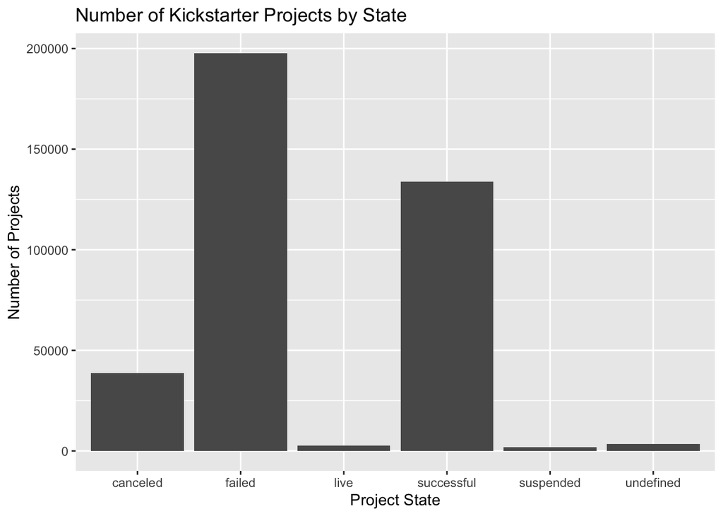

```r
state_summary <- kickstarter |>
  group_by(state) |>
  summarize(project_count = n())

ggplot(state_summary, aes(x = state, y = project_count)) +
  geom_col() +
  labs(
    title = "Number of Kickstarter Projects by State",
    x = "Project State",
    y = "Number of Projects"
  )
```

# Yearly Summary

```r
year_summary <- kickstarter|>
  group_by(launched_year) |>
  summarize(
    count = n(),
    success_count = sum(state == "successful"),
    percent_success = (success_count / count) * 100,
    median_pledged = median(usd_pledged_real, na.rm = TRUE)
  ) |>
  arrange(launched_year)

print(year_summary)
```

```
# A tibble: 11 × 5
   launched_year count success_count percent_success median_pledged
           <dbl> <int>         <int>           <dbl>          <dbl>
 1          1970     7             0             0              0
 2          2009  1329           579            43.6          580
 3          2010 10519          4593            43.7          780
 4          2011 26237         12171            46.4         1021
 5          2012 41165         17892            43.5         1128
 6          2013 44851         19415            43.3         1453
 7          2014 67745         21107            31.2          420
 8          2015 77300         20971            27.1          222
 9          2016 57184         18766            32.8          501
10          2017 52200         18462            35.4          632
11          2018   124             0             0             54.3
```

- **Year used:** I want to track projects by when they started funding so I used launched_year.
- **Percent success:** Calculated success compared to all other possible states to get the total projects deemed successful out of all attempted projects.
- **Pledge summary:** Median of usd_pledged_real is less impacted by outliers.

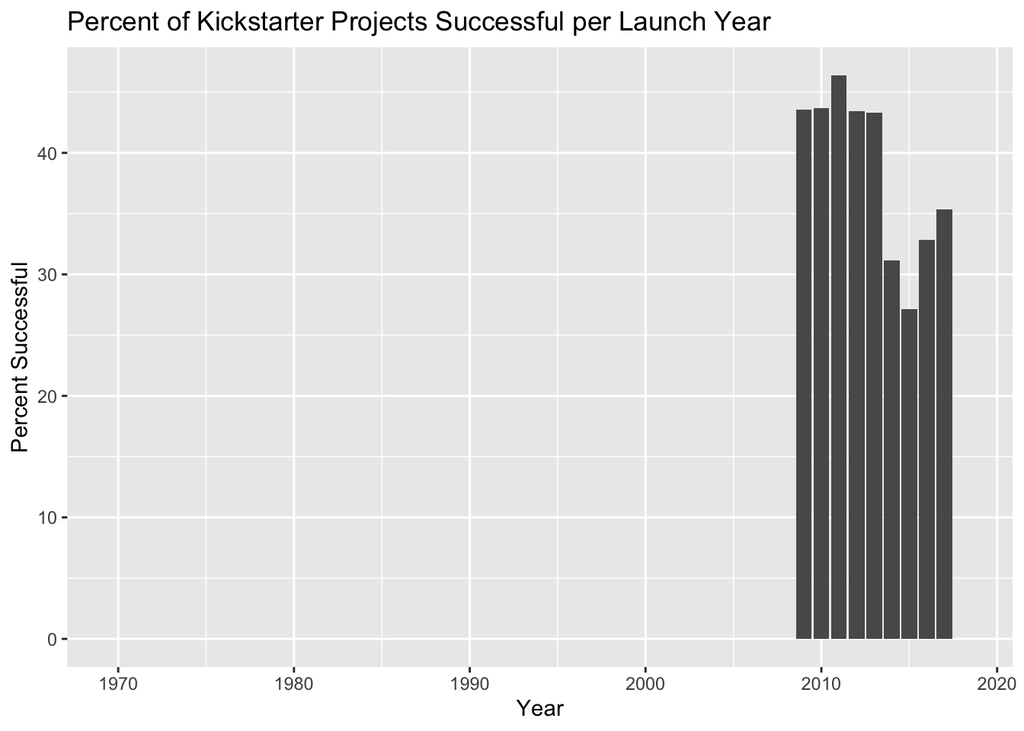

```r
ggplot(year_summary, aes(x = launched_year, y = percent_success)) +
  geom_col() +
  labs(
    title = "Percent of Kickstarter Projects Successful per Launch Year",
    x = "Year",
    y = "Percent Successful"
  )
```

The lowest non-zero success rate occurred for projects launched in 2015, with a success percentage of 27.1. 2018 saw 0 percent success for the projects listed in this data set.

# Unusual Data

The fact that there is data for the year 1970 is unusual and likely represents either missing data or errors. This is because Kickstarter didn’t exist until 2009. 1970 is also before the time of the internet, so impossible for campaigns of any kind to exist on a similar platform.

The launch year of 1970, and therefore the launch date (stored first as char then as a date) is due to a system error when this data was collected. This is because most systems default to 1970-01-01 as the date when no other data is available because they store dates as unix epoch time which is the number of (non-leap) seconds since 00:00:00 [UTC](https://en.wikipedia.org/wiki/Coordinated_Universal_Time) on 1 January 1970.

Is the cause of this error due to data collection? Or was it stored in the original source this way?

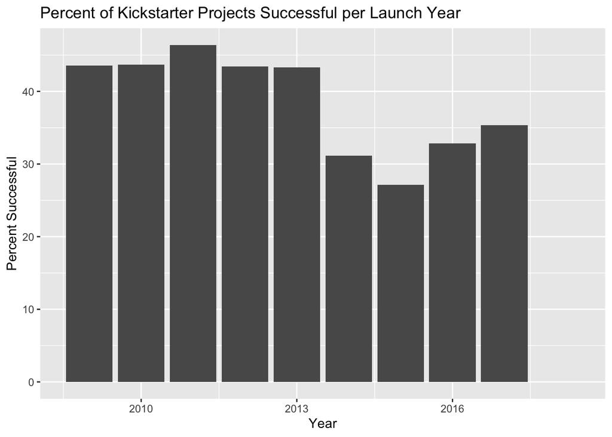

```r
year_summary_filtered <- year_summary |>
  filter(launched_year != 1970)

ggplot(year_summary_filtered, aes(x = launched_year, y = percent_success)) +
  geom_col() +
  labs(
    title = "Percent of Kickstarter Projects Successful per Launch Year",
    x = "Year",
    y = "Percent Successful"
  )
```